## Introduction

There are various ways to measure whether an organization is retained, such as:

- Has a currently active project;
- Has had an active or funded project in the past year (or some other time frame);
- Has an active vetting or status.

As organizations may have different numbers of projects at different times, ‘status’ is the best variable to indicate whether an organization is active (‘Emerging’ or above) or ‘Delinquent’.

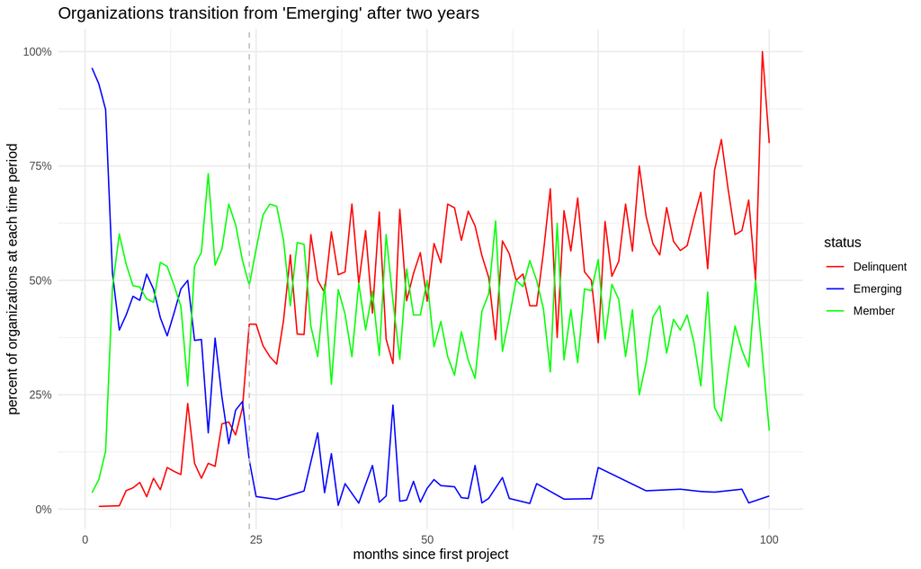

While there will always be natural attrition over time, two years (marked by the vertical dashed line) is the point as which organizations change from ‘Emerging’ to ‘Delinquent’ status. It appears that the percent of organizations at the ‘Committed’ stage remains relatively constant over time. At two years, there is a decrease in the proportion of organizations at the ‘Emerging’ stage and a similar increase in the proportion of organizations at the ‘Delinquent’ status, without a substantial change in the number of ‘Committed’ organizations. Presumably, organizations came move up to a member status at any time, but after two years will automatically become delinquent if they have not taken steps to become a full member.

The goal then, is to determine how we can successfully move organizations from ‘Emerging’ to a ‘Committed’ status within the first two years of their engagement.

How does an organization become ‘Delinquent’?

All organizations who have a vetting expiration date in the past are delinquent. Similarly, organizations do not have an expiration more than two years in the future, regardless of status.

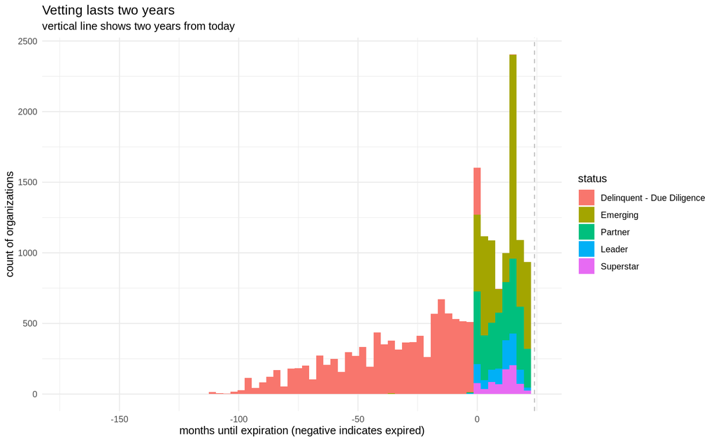

The Accelerator Program allows organizations to skip the ‘Emerging’ status, but those organizations can still fall ‘Delinquent’ after two years.

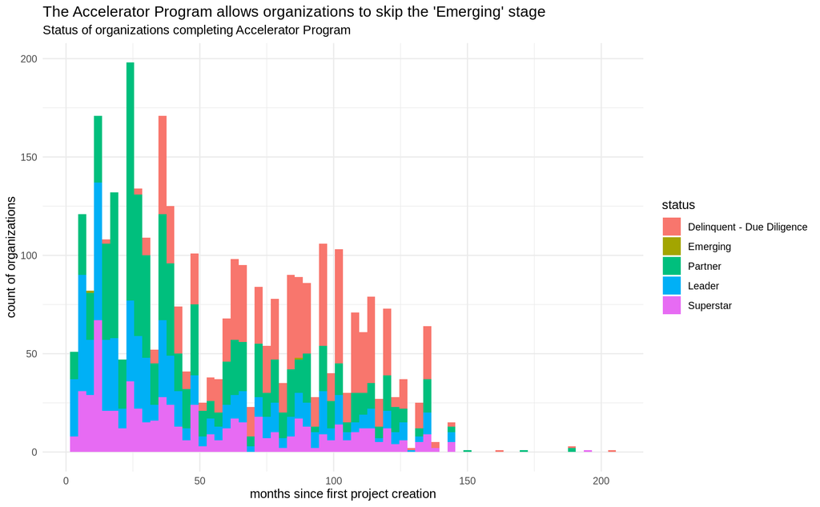

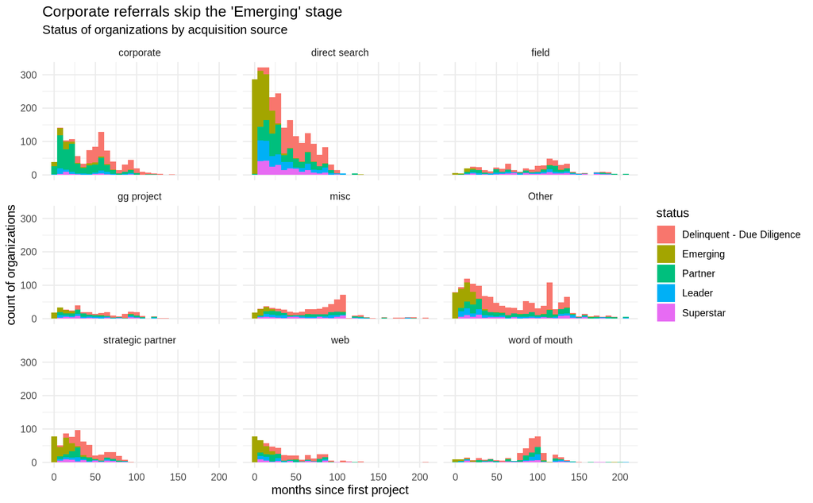

A key lever for increasing retention then is to support organizations in the ‘Emerging’ stage to move up to full membership before becoming ‘Delinquent’.

## Metrics and visualizations

For each metric below, I present some motivation for why it might be useful, a high level visualization to track trends, and an organization-level visualization that may be useful for identifying organizations that require intervention. Each of the high level metrics are present as point-in-time snapshots due to the limitations of the data available, but could also be visualized to understand progress over time. The low-level tables may be useful for segmentation, such as direct outreach to organizations via email, mail, or phone. For these examples, I only present the first few rows of the table.

### Two-year retention and churn

As we saw above, organizations move from ‘Emerging’ to ‘Delinquent’ after two years if they do no re-complete the vetting process. Churn is a measure of how many members from a previous point in time are still now. Because vetting lasts two years, we want to understand churn of organizations from two years ago.

#### Churn: percent of organizations active two years ago that are still active

To determine if someone was active two years ago, we look back two years and see if they already created a project and had an expiration date in the future. Overall, approximately 45% of organizations that were active two years ago are still active.

| currently_active | n | percent |
| --- | --- | --- |
| FALSE | 3239 | 55.4% |
| TRUE | 2608 | 44.6% |

| name | status | number_of_currently_active_projects | vetting_expiration_date |
| --- | --- | --- | --- |
| Samadhan | Partner | 1 | 2021-10-10 |
| Ruchika Social Service Organisation | Leader | 4 | 2022-01-06 |
| Carolina for Kibera, Inc. | Partner | 1 | 2022-05-13 |
| Associacao Saude Crianca | Superstar | 2 | 2021-10-10 |
| The River Fund | Leader | 3 | 2020-11-22 |
| Abalimi Bezekhaya - Planters of the Home | Leader | 1 | 2022-05-27 |
| Room to Read | Partner | 0 | 2022-01-21 |
| Tewa | Superstar | 2 | 2021-10-10 |
| United Nations Development Programme (UNDP): Multi-Partner Trust Fund Office | Partner | 0 | 2020-11-04 |
| Lifeline Energy | Partner | 2 | 2021-12-17 |
| Green Map System | Superstar | 2 | 2021-09-12 |
| Fundacion Escuela Nueva Volvamos a la Gente | Partner | 1 | 2021-10-10 |
| International Bridges to Justice | Emerging | 1 | 2022-08-14 |
| Grupo Ecologico Sierra Gorda I.A.P | Superstar | 2 | 2021-07-24 |
| Himalayan Cataract Project, Inc. | Partner | 3 | 2021-10-09 |
| Freedom Foundation | Partner | 0 | 2021-10-09 |
| CARE | Leader | 14 | 2021-08-08 |
| The Nyaka AIDS Orphans Project | Superstar | 6 | 2021-09-11 |
| SAATH CHARITABLE TRUST | Leader | 2 | 2021-10-10 |
| Afghan Institute of Learning | Superstar | 15 | 2021-12-17 |

### Currently active projects

A key indicator of an organization’s connection with GlobalGiving is whether they are actively posting projects to be funded. The chart below shows that almost all ‘Superstar’ and ‘Leader’ organizations have created a project within the past year.

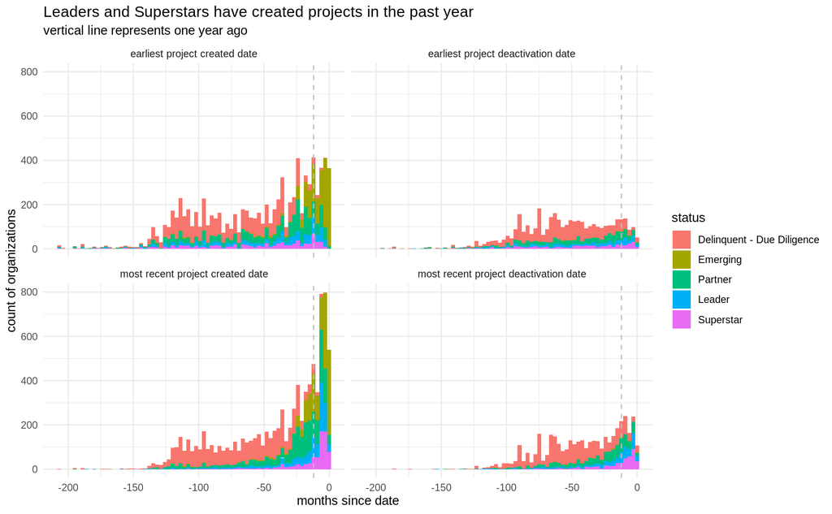

The number of currently active projects is a less strong indicator of an organization’s status, suggesting that having any active project, and the recency of posting that project, is a better metric to track than organizations who have many currently ongoing projects.

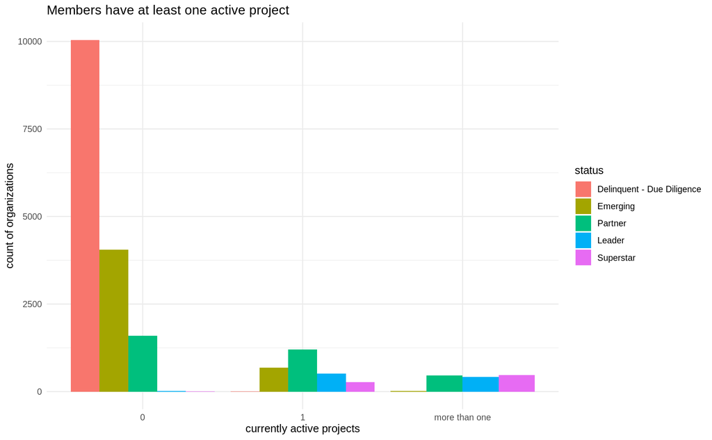

There are two key metrics that we want to track then: number of organizations with at least one active project, and number of organizations that have created a project within the past twelve months.

#### Number of organizations with active projects

| x |
| --- |
| 4038 |

#### Number of organizations who have created a project in the past twelve months

| x |
| --- |
| 2776 |

| name | status | Months since most recent project |
| --- | --- | --- |
| United Nations Development Programme (UNDP): Multi-Partner Trust Fund Office | Partner | 194 |
| Center for Inspired Teaching | Partner | 194 |
| Aravind Eye Foundation | Leader | 185 |
| Abalimi Bezekhaya - Planters of the Home | Leader | 180 |
| Friends of Warm Hearth, Inc. | Leader | 160 |
| Empowering Women of Nepal | Partner | 159 |
| Friends of Szadvar (Szadvarert Barati Kor) | Superstar | 147 |
| WINGS | Leader | 142 |
| Solar Household Energy, Inc. (SHE, Inc.) | Emerging | 140 |
| Native American Youth and Family Center | Emerging | 139 |
| Education East Africa | Leader | 138 |
| Clinica Verde | Partner | 138 |
| Portland Art Museum | Partner | 137 |
| Take 2: An Innovative Program for Social Learning | Partner | 136 |
| Lynn Sage Foundation | Superstar | 136 |
| Girls to Women | Partner | 136 |
| Advancement of Girls’ Education (AGE Africa) | Partner | 134 |
| Critical Exposure | Partner | 134 |
| Stop the Silence: Stop Child Sexual Abuse | Leader | 134 |
| Mr. Holland’s Opus Foundation | Partner | 133 |

### Last login

How recently an organization has logged-in to their account is similarly a strong indicator of their status. Nearly all ‘Leaders’ and ‘Superstars’ have logged in during the past six months.

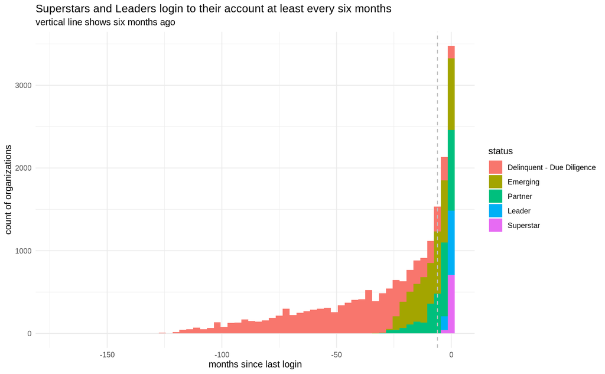

The key metric to track here then is the number and percent organizations who have logged into their account in the past six months, by their status.

#### Number of organizations who have logged into their account in the past six months

| n | pct |
| --- | --- |
| 6626 | 0.3354257 |

#### Number of organizations who have logged into their account in the past six months by status

| status | n | pct |
| --- | --- | --- |
| Delinquent - Due Diligence | 641 | 0.0638192 |
| Emerging | 2076 | 0.4360428 |
| Partner | 2215 | 0.6811193 |
| Leader | 950 | 0.9989485 |
| Superstar | 744 | 0.9973190 |

A table similar to the one below would allow staff to extract a list of organizations who have more than six months but less than twelve months since their last login.

| name | last_login | status | months_since_login |
| --- | --- | --- | --- |
| Nowzad Dogs NFP | 2019-10-20 14:41:13 | Emerging | 11 |
| The Project HEAL | 2019-10-20 19:43:24 | Partner | 11 |
| Evangelical Lutheran Development service | 2019-10-21 03:25:47 | Emerging | 11 |
| Kids Run Free | 2019-10-21 07:25:19 | Partner | 11 |
| Led2Serve | 2019-10-21 10:02:07 | Emerging | 11 |
| Led2Serve, Inc | 2019-10-21 10:02:07 | Emerging | 11 |
| Genesis Innovation Academy | 2019-10-21 13:34:38 | Emerging | 11 |
| Mashantucket Pequot Youth Council | 2019-10-21 14:21:18 | Emerging | 11 |
| Outdoor Journeys Inc | 2019-10-21 14:34:07 | Emerging | 11 |
| Cure International | 2019-10-21 16:41:30 | Emerging | 11 |
| Prairie High School JROTC | 2019-10-21 18:29:50 | Emerging | 11 |
| Harmony Diabetes Foundation | 2019-10-21 18:58:02 | Emerging | 11 |
| Rose City Gay Freedom Bands | 2019-10-21 22:55:32 | Emerging | 11 |
| Engineering for Kids of Metro Atlanta | 2019-10-22 00:03:25 | Emerging | 11 |
| COMMUNITY CONCERN OF ORPHAN AND DEVELOPMENT ASSOCIATION | 2019-10-22 05:19:24 | Emerging | 11 |
| Mpunzana Primary School | 2019-10-22 06:38:57 | Partner | 11 |
| Non-Violence Project Foundation | 2019-10-22 07:09:41 | Emerging | 11 |
| association errahma des handicapees | 2019-10-22 07:14:40 | Emerging | 11 |
| Prevent Breast Cancer | 2019-10-22 09:14:17 | Emerging | 11 |
| Associacao Cearense de Beisebol | 2019-10-22 09:20:29 | Emerging | 11 |

## Next steps and future analyses

### Comparisons over time

One potential issue with this analysis is that is presents a snapshot at the current time. Many of the above measures will be useful to examine overtime, as we want to ensure we are making meaningful progress toward our goals.

Similarly, current issues such as the COVID-19 pandemic or and increasing need for organizations to generate funds in more creative ways may limit the ways that the current snapshot can be compared to previous points in time.

### Predictive following descriptive

With more longitudinal data, we may be able to develop some predictions for which organizations are likely to churn. For example, we might develop a model of organizations likely to churn so that we can intervene with those organizations in some way. Or we may want to run some tests to infer which factors which interventions are effective an increasing retention.

## Appendix

Below are some additional notes about this analysis.

### Duplicate records

In the data there are 57 organizations with duplicate names but unique IDs. I treated these as unique organizations for this analysis, but it’s possible they should have been handled differently based on why they are duplicates.

### Survival analysis

A chart like the one below, might be useful for understanding if retention is improving over time. Because of limitations with the data available, this chart doesn’t show a valid measure of churn, but demonstrates what a chart tracking this could look like.

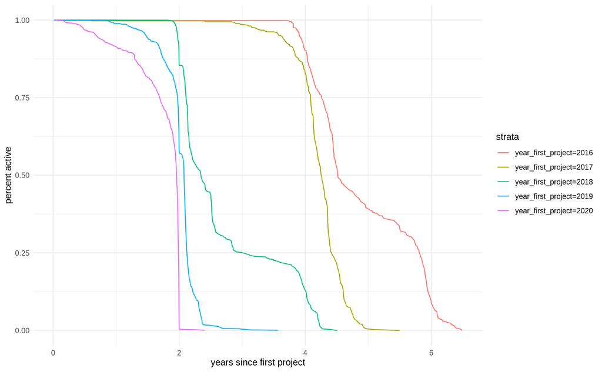

## Country

There does not appear to be any discernible trend between country/region and the percent of organizations that are delinquent.

```
##              country_of_registration    n
## 1                      United States 7773
## 2                     United Kingdom 1131
## 3       Tanzania, United Republic of  304
## 4  Congo, Democratic Republic of the  104
## 5                China-Hong Kong SAR   35
## 6                       China-Taiwan   28
## 7                           Eswatini   17
## 8               Moldova, Republic of   17
## 9                        Gambia, The   15
## 10               Trinidad and Tobago   15
## 11                              <NA>   13
## 12                     Côte d'Ivoire   12
## 13                        East Timor    8
## 14                      Bahamas, The    7
## 15            Congo, Republic of the    7
## 16  Lao People's Democratic Republic    7
## 17            Macedonia, Republic of    5
## 18               Antigua and Barbuda    2
## 19            British Virgin Islands    1
## 20             Caribbean Netherlands    1
## 21                           Curaçao    1
## 22                             Macau    1
## 23             Saint Kitts and Nevis    1
## 24              Syrian Arab Republic    1
```

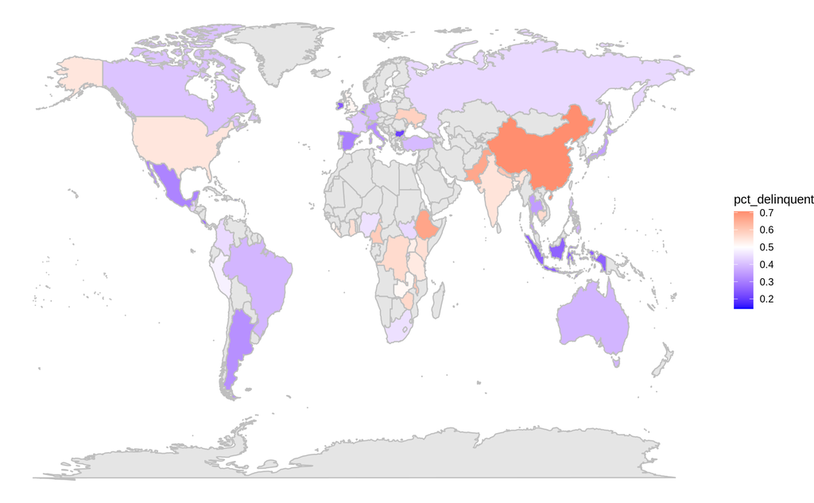

```
## # A tibble: 20 x 4
##    country_of_registration          n_delinquent     n pct_delinquent
##    <chr>                                   <int> <int>          <dbl>
##  1 China                                      65    92          0.707
##  2 Ethiopia                                   50    75          0.667
##  3 Pakistan                                  199   300          0.663
##  4 Nepal                                     102   169          0.604
##  5 Malawi                                     68   113          0.602
##  6 Cameroon                                  113   190          0.595
##  7 Ukraine                                    34    58          0.586
##  8 Zimbabwe                                   64   112          0.571
##  9 Cambodia                                   46    81          0.568
## 10 Democratic Republic of the Congo           59   104          0.567
## 11 Kenya                                     405   724          0.559
## 12 Ghana                                     154   276          0.558
## 13 India                                     724  1313          0.551
## 14 USA                                      4253  7773          0.547
## 15 Liberia                                    41    76          0.539
## 16 Tanzania                                  164   304          0.539
## 17 Uganda                                    425   802          0.530
## 18 Bangladesh                                 55   106          0.519
## 19 UK                                        584  1131          0.516
## 20 Sierra Leone                               35    68          0.515
```